# Análisis del impacto en Twitter: PP y PSOE

## Objetivo

La intensa actividad en las redes sociales las ha convertido en fuentes de grandes volúmenes de información. En caso de Twitter, la extracción y el análisis de los datos propios de usuarios y mensajes, permitirá obtener múltiples resultados estadísticos. En este sentido y el marco de unas cercanas elecciones epañolas, se pretende realizar un análisis de los datos que se pueden obtener a partir de la cuenta de twitter oficial de los partidos políticos.

## Los contactos

### Extracción de información

Primeramente, después de la autenticación a la API de Twitter se obtiene un conjunto *data frame* con los datos de 80 de los *Followers* del PP:

```r
twitterAuthentication()
```

```
## [1] "Using direct authentication"
```

```r
# Data frames with PP profile information
tuserPp <- getUser("PPopular")

# PP data frames with information of 80 followers
followersDataFramePp <<- getFollowersDataFrame(tuserPp, 80)
```

### Ránking de usuarios influyentes

Inicialmente, tratamos de identificar los más relevantes *Followers* del partido.

```r
# PP friends analysis
topFollowersPp <<- getTopFollowers(followersDataFramePp)
topFriendsPp <<- getTopFriends(followersDataFramePp)
topTweetsPp <<- getTopTweets(followersDataFramePp)
```

De este modo, en la siguiente tabla se visualizan: los usuarios que siguen a un mayor número de *Friends*, los más seguidos por *Followers* y los más activos en el envío de mensajes (*Tweets*).

Tabla 1. Usuarios influyentes en Twitter

|  | Usuario | # Followers | Usuario | # Friends | Usuario | # Tweets |
| --- | --- | --- | --- | --- | --- | --- |
| 1 | Jajijuja | 622 | mikel_ni | 2007 | cas_ines | 9189 |
| 2 | cas_ines | 453 | mafegalo | 1708 | Jajijuja | 6201 |
| 3 | claraportilla99 | 333 | cas_ines | 1375 | lorafengari | 5744 |
| 4 | almuglb | 322 | maurobaldi | 818 | Pepe_Bujalance | 5246 |
| 5 | AlombiS | 283 | lorafengari | 641 | claraportilla99 | 4110 |
| 6 | maurobaldi | 226 | Pepe_Bujalance | 548 | inmilacontri | 2970 |
| 7 | Pepe_Bujalance | 200 | 91Fany | 512 | AlombiS | 1991 |
| 8 | mafegalo | 194 | Jajijuja | 506 | RamonRegany | 1049 |
| 9 | lorafengari | 147 | almuglb | 387 | almuglb | 1008 |
| 10 | inmilacontri | 138 | ricardopeca83 | 303 | mercyrojas1 | 711 |

### Vínculo entre usuarios

```
## [1] "NA"
```

### Actividad en la red

Adicionalmente, podemos extraer el comportamiento de lo usuarios mediante la distribución de su nivel de actividad en la red.

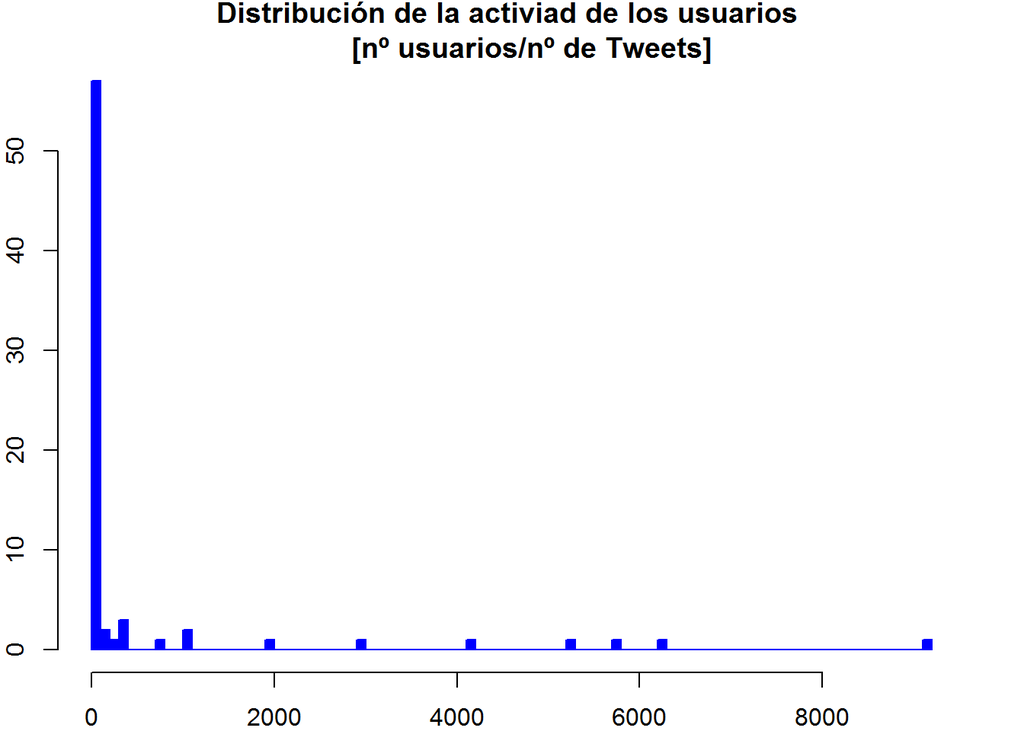

### Geolocalización

Finalmente, mediante la ubicación de los usuarios, podemos observar su distribución geográfica en el territorio.

De este modo, ánalogamente a los cálculos ya realizados, se obtienen los datos del **PSOE** (https://twitter.com/PSOE) y se realiza la comparativa de distribuciones geográficas entre los *Followers* de **PP** y **PSOE**.

[figure not shown]

## Los Tweets

Es posible extender el análisis a los *Tweets* enviados por los perfiles de usuario de los partidos políticos. En el estudio efectuado, se han tomado los últimos 1000 *Tweets* escritos por **PP** y **PSOE**.

```r
tweetsOfUserDataFramePsoe <<- getUserTweetsDataFrame(tuserPsoe, 1000)
tweetsOfUserDataFramePp <<- getUserTweetsDataFrame(tuserPp, 1000)
```

De este modo, es posible obtener el historial temporal con la actividad en la red y comparar la cantidad de mensajes enviados entre partidos.

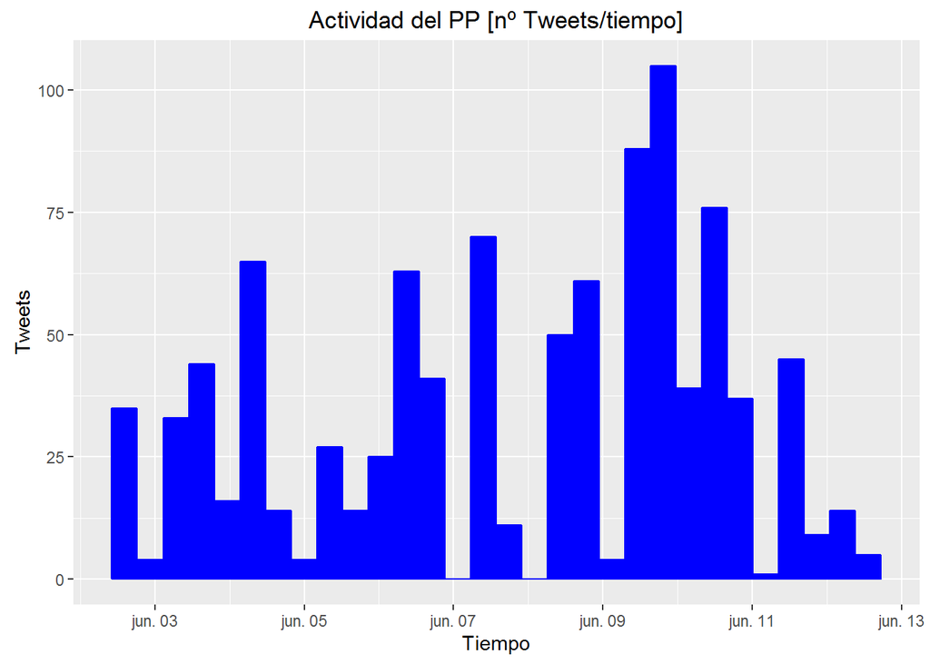

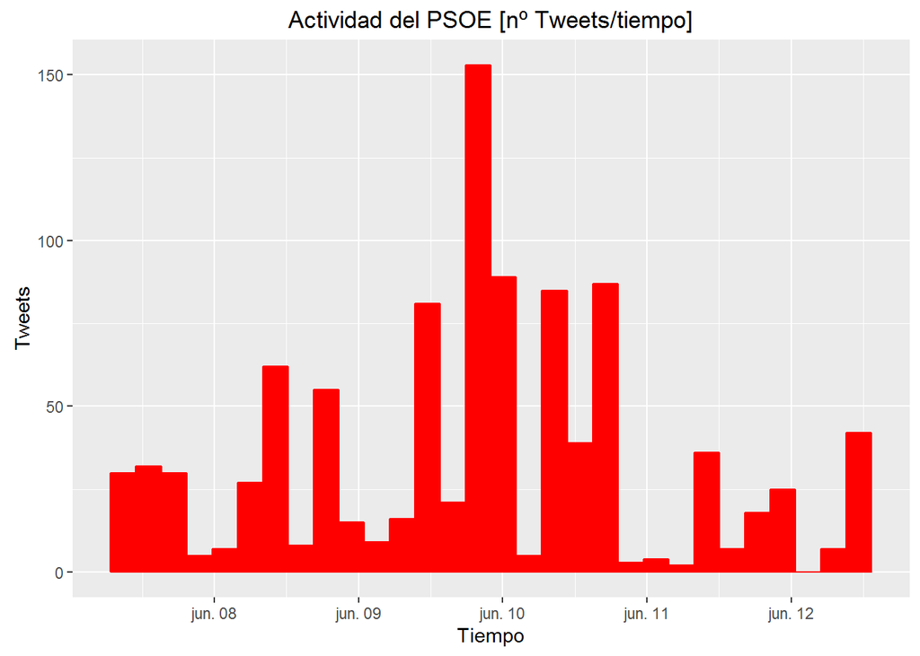

A nivel de la actividad global en red, se analizan los últimos 1000 *Tweets* que tratan sobre el **PP** o el **PSOE** enviados dentro del territorio español.

```r
twitterAuthentication()
```

```
## [1] "Using direct authentication"
```

```r
tweetsDataFramePp <- getTweetsDataFrame("PP", "40.2,-3.71,700km",
                                         number=1000)
tweetsDataFramePsoe <- getTweetsDataFrame("PSOE", "40.42,-3.71,700km",
                                           number=1000)
```

A partir de los *Tweets* obtenidos sobre los diferentes partidos políticos, es posible analizar su contenido. De este modo, se estudia cuál de los hilos temáticos correspondientes usa un peor tono e incluye un mayor número de palabrotas.

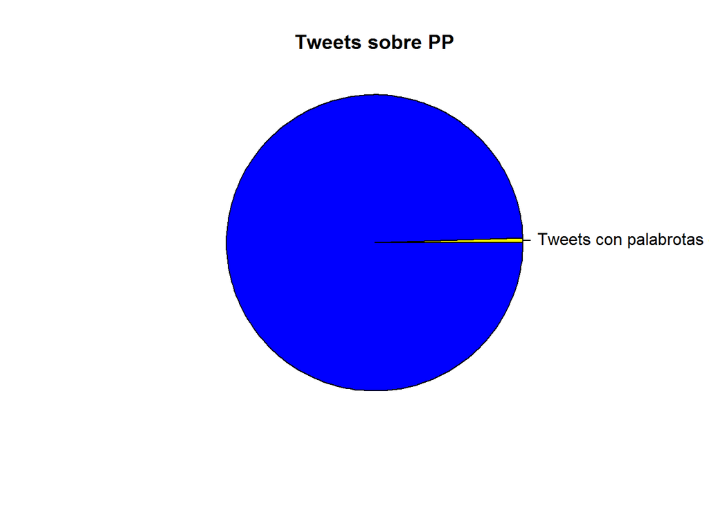

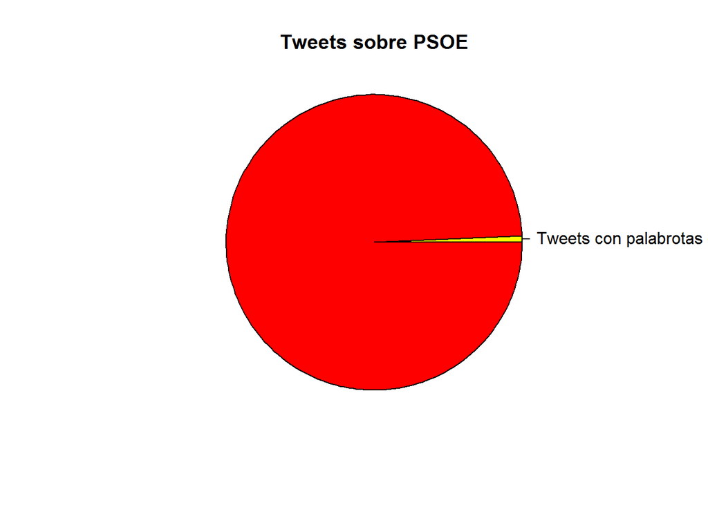

```r
keyWordsList <- readLines("data/insultos.txt")

keyWordsDataFramePp <<- getTweetsWithKeyword(tweetsDataFramePp,
                                            keyWordsList)
keyWordsDataFramePsoe <<- getTweetsWithKeyword(tweetsDataFramePsoe,
                                              keyWordsList)
```